# **Diplomado IA: Aplicaciones de Inteligencia Artificial I - Parte 2**. Práctico 22: Generación de resúmenes

**Profesores:**

- Felipe del Río

**Ayudante:**

- Bianca del Solar

# **Instrucciones Generales**

El siguiente práctico se debe realizar de forma **individual**. El formato de entregar es el **archivo .ipynb con todas las celdas ejecutadas**. Todas las preguntas deben ser respondida en celdas de texto. No se aceptará el *output* de una celda de código como respuesta.

**Nombre:** Roberto Araneda

El siguiente práctico cuanta con 3 secciones donde cada una contendrá 1 o más actividades a realizar. Algunas actividades correspondrán a escribir código y otras a responder preguntas.

Se recomienda **fuertemente** revisar las secciones donde se entrega código porque algunas actividades de código pueden reutilizar el mismo código pero con cambios en algunas líneas.

# **Agenda**

> Diplomado IA: Aplicaciones de Inteligencia Artificial I - Parte 2. Práctico 22: Generación de resúmenes

> Instrucciones Generales

> Agenda

> Parte II: Generación de Resumenes Abstractivos ft. Huggingface's T5

> > Preámbulo

> > Resumenes Abstractivos usando T5

> > Evaluación Cualitativa

> > Actividad 2

> > Actividad 3 - Parámetros de Decodificación

> > > Número de Rayos de Beam Search

> > > > num_beams=5

> > > > num_beams=20

> > > Utilicemos aleatoriedad para samplear los resumenes

> > > > do_sample=False

> > > > do_sample=True

> > > Nucleus Sample

> > > > top_p=0.95

> > > > top_p=0.9

> > > Temperatura

> > > > temperature=0.6

> > > > temperature=1.5

> > Evaluemos el Modelo

> > > Dataset CNN/DailyMail

> > > Evaluación

> > > Inspección de Ejemplo

> > > Evaluación Completa sobre CNN/DailyMail

> > Actividad 4

# Parte II: Generación de Resumenes Abstractivos ft. Huggingface's T5

Agradecemos a Carlos Aspillaga por el código base para esta sección.

En esta última secciónn veremos como se comporta un modelo abstractivo basado en Transformers, específicamente el [modelo T5](https://arxiv.org/pdf/1910.10683.pdf). Este modelo está basado en el transformer original (completo, no solo el encoder como BERT o decoder como GPT-X) el cual tiene un entrenamiento no supervisado en generación de texto basado en el de BERT. Y está pensado para luego ser especializado en una tarea relevante de generación, como generación de automática de resumenes, que posea menor cantidad de datos.

[figure not shown]

## Preámbulo

Primero debemos descargar distintas utilidades para realizar la actividad.

Debemos importar algunas de las librerías que ocuparemos durante esta actividad, como `pytorch` y `transformers`.

```python
import warnings
warnings.filterwarnings('ignore')
```

```python
# Instalamos los paquetes a utilizar.
!pip install -qqq rouge-score
!pip install -qqq 'transformers[torch]'==4.45.2
!pip install -qqq datasets==3.0.1
!pip install -qqq evaluate==0.4.3
!pip install -qqq sentencepiece==0.1.99
```

[output not shown]

```python
import json
import random
import matplotlib.pyplot as plt
import numpy as np
import torch
from torch.utils.data import DataLoader
from transformers import T5Tokenizer, T5ForConditionalGeneration, T5Config
from tqdm.auto import tqdm
```

```python
import textwrap

# Funciones auxiliares para mostrar los resultados

def bold(text):
  return '\033[1m' + text + '\033[0m'
```

## Resumenes Abstractivos usando T5

A continuación utilizaremos un modelo pre-entranado que nos provee la librería `transformers` de hugginface y lo usaremos para generar resumenes.

Utilizaremos la versión *small* de este modelo. Tiene 60 millones de parámetros (vs. 220 millones en su versión *base* y 770 millones su versión *large*) y tanto el encoder y el decoder tienen los siguientes parámetros:

- $d_{model} = 512$
- $d_{ff} = 2,048$
- 8 heads
- 6 capas

```python
t5_model = 't5-small' # Podríamos usar un modelo más grande, por e.g.: 't5-base'

device = torch.device('cuda')
model = T5ForConditionalGeneration.from_pretrained(t5_model).to(device)
tokenizer = T5Tokenizer.from_pretrained(t5_model)
```

```
You are using the default legacy behaviour of the <class 'transformers.models.t5.tokenization_t5.T5Tokenizer'>. This is expected, and simply means that the `legacy` (previous) behavior will be used so nothing changes for you. If you want to use the new behaviour, set `legacy=False`. This should only…
```

## Evaluación Cualitativa

Siempre es buena idea evaluar de forma cualitativa los modelos que entrenamos. Esto nos permite hacernos una intuición de cómo está funcionando y qué problemas puede tener.

En esta parte de la actividad la idea es probar el modelo utilizando noticias y/o textos de la "vida real". Así veamos cómo funcionaría el modelo en caso de que lo usasemos para una nueva aplicación.

```python
text ="""
The US has "passed the peak" on new coronavirus cases, President Donald Trump said and predicted that some states would reopen this month.
The US has over 637,000 confirmed Covid-19 cases and over 30,826 deaths, the highest for any country in the world.
At the daily White House coronavirus briefing on Wednesday, Trump said new guidelines to reopen the country would be announced on Thursday after he speaks to governors.
"We'll be the comeback kids, all of us," he said. "We want to get our country back."
The Trump administration has previously fixed May 1 as a possible date to reopen the world's largest economy, but the president said some states may be able to return to normalcy earlier than that.
"""

prefix = "summarize: "

preprocess_text = text.strip().replace("\n","")
t5_prepared_text = prefix + preprocess_text
print(bold("Texto Original:"))
print(textwrap.fill(text, width=70), end='\n\n')
```

```
Texto Original:
 The US has "passed the peak" on new coronavirus cases, President
Donald Trump said and predicted that some states would reopen this
month. The US has over 637,000 confirmed Covid-19 cases and over
30,826 deaths, the highest for any country in the world. At the daily
White House coronavirus briefing on Wednesday, Trump said new
guidelines to reopen the country would be announced on Thursday after
he speaks to governors. "We'll be the comeback kids, all of us," he
said. "We want to get our country back." The Trump administration has
previously fixed May 1 as a possible date to reopen the world's
largest economy, but the president said some states may be able to
return to normalcy earlier than that.
```

```python
NUM_SENTENCES = 5 # number of output summaries
NUM_BEAMS = 20 # must be >= NUM_SENTENCES

tokenized_text = tokenizer.encode(t5_prepared_text, return_tensors="pt").to(device)

# summmarize
summary_ids = model.generate(tokenized_text,
                             num_beams=NUM_BEAMS,
                             no_repeat_ngram_size=2,
                             num_return_sequences=NUM_SENTENCES,
                             min_length=30,
                             max_length=100,
                             early_stopping=True).cpu()

print(bold("Texto resumido: \n"))
for i, beam_output in enumerate(summary_ids):
  output = tokenizer.decode(beam_output, skip_special_tokens=True)
  print(bold(f"Resumen {i}:"))
  print(textwrap.fill(output, width=70), end='\n\n')

tokenized_text = None # Free GPU memory
```

```
Texto resumido:

Resumen 0:
the u.s. has over 637,000 confirmed cases and over 30,826 deaths, the
highest for any country in the world. the president says some states
may be able to return to normalcy earlier than that.

Resumen 1:
the us has over 637,000 confirmed cases and over 30,826 deaths, the
highest for any country in the world. the president says some states
may be able to return to normalcy earlier than that.

Resumen 2:
the u.s. has over 637,000 confirmed cases and over 30,826 deaths, the
highest for any country in the world. the president said some states
may be able to return to normalcy earlier than that.

Resumen 3:
the u.s. has over 637,000 confirmed cases and over 30,826 deaths, the
highest for any country in the world. the president says some states
may be able to return to normalcy earlier than that. "we want to get
our country back," he says.

Resumen 4:
the u.s. has over 637,000 confirmed cases and over 30,826 deaths, the
highest for any country in the world. the president said some states
may be able to return to normalcy earlier than that. "we want to get
our country back," he said.
```

## Actividad 2

1. Busque una noticia reciente (en inglés) y genere un resumen abstractivo en base a esta.

**Importante:** Preocupese de que el texto no sea tan largo que el procesamiento no quepa en la GPU.

```python
my_news = """
The US Food and Drug Administration has approved DermaSensor, the first AI-powered device to diagnose skin cancer noninvasively at the point of care.
DermaSensor is a wireless, handheld device that uses spectroscopy to examine skin lesions at the cellular and subcellular level, then analyzes those characteristics with an FDA-cleared algorithm.
In clinical testing, the device demonstrated 96% sensitivity across all 224 types of skin cancer studied, including melanoma, basal cell carcinoma, and squamous cell carcinoma.
A negative result had a 97% chance of being benign across all skin cancers.
The approval is expected to help primary care physicians identify cancerous lesions earlier, without an immediate referral to a dermatologist.
"""

preprocess_text = my_news.strip().replace("\n","")
t5_prepared_Text = "summarize: " + preprocess_text
print(bold("Texto Original:"))
print(textwrap.fill(my_news, width=70), end='\n\n')

tokenized_text = tokenizer.encode(t5_prepared_Text, return_tensors="pt").to(device)

NUM_SENTENCES = 5 # number of output summaries
NUM_BEAMS = 20 # must be >= NUM_SENTENCES

# summmarize
summary_ids = model.generate(tokenized_text,
                             num_beams=NUM_BEAMS,
                             no_repeat_ngram_size=2,
                             num_return_sequences=NUM_SENTENCES,
                             min_length=30,
                             max_length=100,
                             early_stopping=True).cpu()

print(bold("Texto resumido: \n"))
for i, beam_output in enumerate(summary_ids):
  output = tokenizer.decode(beam_output, skip_special_tokens=True)
  print(bold(f"Resumen {i}:"))
  print(textwrap.fill(output, width=70), end='\n\n')

tokenized_text = None # Free GPU memory
```

```
Texto Original:
 The US Food and Drug Administration has approved DermaSensor, the
first AI-powered device to diagnose skin cancer noninvasively at the
point of care. DermaSensor is a wireless, handheld device that uses
spectroscopy to examine skin lesions at the cellular and subcellular
level, then analyzes those characteristics with an FDA-cleared
algorithm. In clinical testing, the device demonstrated 96%
sensitivity across all 224 types of skin cancer studied, including
melanoma, basal cell carcinoma, and squamous cell carcinoma. A
negative result had a 97% chance of being benign across all skin
cancers. The approval is expected to help primary care physicians
identify cancerous lesions earlier, without an immediate referral to a
dermatologist.

Texto resumido:

Resumen 0:
the first AI-powered device to diagnose skin cancer noninvasively at
the point of care. the device is expected to help primary care
physicians identify cancerous lesions earlier, without an immediate
referral to a dermatologist.

Resumen 1:
the first AI-powered device to diagnose skin cancer noninvasively at
the point of care. the device is expected to help primary care
physicians identify cancerous lesions earlier, without immediate
referral to a dermatologist.

Resumen 2:
the first AI-powered device to diagnose skin cancer noninvasively at
the point of care. the device is expected to help primary care
physicians identify cancerous lesions sooner, without an immediate
referral to a dermatologist.

Resumen 3:
the first AI-powered device to diagnose skin cancer noninvasively at
the point of care. the device is expected to help primary care
physicians identify cancerous lesions earlier without an immediate
referral to a dermatologist.

Resumen 4:
DermaSensor is the first AI-powered device to diagnose skin cancer
noninvasively at the point of care. the device uses spectroscopy to
examine skin lesions at cellular and subcellular level, then analyze
those characteristics with an FDA-cleared algorithm.
```

2. En base a la noticia anterior y los candidatos a resumenes generados, conteste las siguientes preguntas.

```python
#@title ¿Con cuál de los candidatos generados se quedaría como resumen final? Justifica brevemente.
R = "El Resumen 4, porque es el único que nombra explícitamente 'DermaSensor' y describe la tecnología (spectroscopy + algoritmo FDA-cleared); los otros cuatro nunca mencionan el nombre del dispositivo. Ninguno es ideal —todos omiten que fue la FDA quien lo aprobó y descartan las cifras clínicas (96% sensibilidad, 224 tipos, 97%)— pero el 4 es el más informativo." #@param {type:"string"}
```

```python
#@title De los mecanismos vistos en clases nombre **uno** para aumentar la diversidad de los candidatos generados por el modelo.
R = "La temperatura: subir la temperatura (T>1) aplana la distribución de probabilidad antes del softmax, aumentando la variabilidad de los tokens generados y, por tanto, la diversidad de los candidatos." #@param {type:"string"}
```

3. Elija dos o tres párrafos de un libro a su elección (en inglés), y genere un resumen en base este utilizando el código a continuación.

**Importante:** Preocupese de que el texto no sea tan largo que el procesamiento no quepa en la GPU.

```python
other_text ="""
It is a truth universally acknowledged, that a single man in possession of a good fortune, must be in want of a wife.
However little known the feelings or views of such a man may be on his first entering a neighbourhood, this truth is so well fixed in the minds of the surrounding families, that he is considered the rightful property of some one or other of their daughters.
"My dear Mr. Bennet," said his lady to him one day, "have you heard that Netherfield Park is let at last?"
Mr. Bennet replied that he had not.
"But it is," returned she; "for Mrs. Long has just been here, and she told me all about it."
"""

preprocess_text = other_text.strip().replace("\n","")
t5_prepared_Text = "summarize: " + preprocess_text
print(bold("Texto Original:"))
print(textwrap.fill(other_text, width=70), end='\n\n')

tokenized_text = tokenizer.encode(t5_prepared_Text, return_tensors="pt").to(device)

NUM_SENTENCES = 5 # number of output summaries
NUM_BEAMS = 20 # must be >= NUM_SENTENCES

# summmarize
summary_ids = model.generate(tokenized_text,
                             num_beams=NUM_BEAMS,
                             no_repeat_ngram_size=2,
                             num_return_sequences=NUM_SENTENCES,
                             min_length=30,
                             max_length=100,
                             early_stopping=True).cpu()

print(bold("Texto resumido: \n"))
for i, beam_output in enumerate(summary_ids):
  output = tokenizer.decode(beam_output, skip_special_tokens=True)
  print(bold(f"Resumen {i}:"))
  print(textwrap.fill(output, width=70), end='\n\n')

tokenized_text = None # Free GPU memory
```

```
Texto Original:
 It is a truth universally acknowledged, that a single man in
possession of a good fortune, must be in want of a wife. However
little known the feelings or views of such a man may be on his first
entering a neighbourhood, this truth is so well fixed in the minds of
the surrounding families, that he is considered the rightful property
of some one or other of their daughters. "My dear Mr. Bennet," said
his lady to him one day, "have you heard that Netherfield Park is let
at last?" Mr. Bennet replied that he had not. "But it is," returned
she; "for Mrs. Long has just been here, and she told me all about it."

Texto resumido:

Resumen 0:
little known the feelings or views of such a man may be on his first
entering the neighbourhood. he is considered the rightful property of
some one or other of their daughters, says his lady to him. "for Mrs.
Long has just been here, and she told me all about it."

Resumen 1:
little known the feelings or views of such a man may be on his first
entering the neighbourhood. he is considered the rightful property of
some one or other of their daughters, said his lady to him. "for Mrs.
Long has just been here, and she told me all about it."

Resumen 2:
little known the feelings or views of such a man may be on his first
entering the neighbourhood. he is considered the rightful property of
some one or other of their daughters, his lady tells him. "for Mrs.
Long has just been here, and she told me all about it."

Resumen 3:
little known the feelings or views of such a man may be on his first
entering the neighbourhood. he is considered the rightful property of
some one or other of their daughters, she tells him. "for Mrs. Long
has just been here, and she told me all about it."

Resumen 4:
little known the feelings or views of such a man may be on his first.
he is considered the rightful property of some one or other of their
daughters.
```

Responda las siguientes preguntas en base al texto elegido y los resumenes generados para este.

```python
#@title Indique el libro que eligió.
R = "Pride and Prejudice, de Jane Austen (1813). Párrafos iniciales del Capítulo 1 (dominio público)." #@param {type:"string"}
```

```python
#@title ¿Con cuál de los candidatos generados se quedaría como resumen final?
R = "El Resumen 1, por descarte: es el menos malo. Mantiene 'said his lady to him' sin inventar una atribución (a diferencia de los resúmenes 2 y 3, que con 'she tells him' atribuyen falsamente a la Sra. Bennet una frase que es narración de la autora), y no se trunca a media frase como el Resumen 4. Aun así, ninguno captura el hecho central (que Netherfield Park fue alquilado), por lo que la calidad es baja." #@param {type:"string"}
```

```python
#@title ¿Cómo se compara la calidad del resumen en comparación al obtenido utilizando una noticia?
R = "El resumen del libro salió bastante peor que el de la noticia. Con la noticia el resultado fue claro y bien redactado, y se entendía de qué trataba. Con el libro, en cambio, el modelo no captó la idea principal (que se anuncia que alquilaron una casa), juntó frases sueltas que no tienen relación entre sí y hasta cambió quién dice qué, poniendo en boca de un personaje algo que en realidad no dijo. Incluso uno de los resúmenes quedó cortado a la mitad de una frase. La razón es que este modelo fue entrenado para resumir noticias, donde lo importante suele estar al principio y en datos concretos; un texto de un libro está escrito de otra forma, y al no encontrar ese patrón, el modelo arma el resumen con pedazos al azar." #@param {type:"string"}
```

```python
#@title Proponga **una** medida para mejorar la calidad del resumen obtenido.
R = "Usar un modelo más grande o uno entrenado específicamente para el tipo de texto que se quiere resumir. Acá se usó la versión más pequeña entrenada con noticias; cambiarla por una versión más grande (t5-base o t5-large) o por un modelo entrenado con textos parecidos al que uno necesita daría resúmenes más completos y confiables." #@param {type:"string"}
```

## Actividad 3 - Parámetros de Decodificación

Exploremos ahora cómo distintos parámetros de decodificación afectan la generación de texto del modelo. Utilizaremos la misma noticia de la actividad anterior para esto, de manera de entender mejor los efectos de cada uno.

Como vimos en clase veremos el efecto de modificar los siguientes parámetros del método `generate` del modelo:

- Número de 'rayos' de beam search, `num_beams`.
- Samplear (en vez de decodificación greedy), `do_sample`.
- Hacer nucleus sample, `top_p`.
- Temperatura, `temperature`.

**Actividad:** Despues de cada parámetro de modificación analice brevemente que cambios observa entre ambos ejemplos generados.

Veamos nuevamente la noticia que estamos utilizando, y generemos resumenes alterando un parámetro a la vez. Seguiremos mostrando 5 resultados de manera de ver la diferencia entre ellos.

```python
text ="""
The US has "passed the peak" on new coronavirus cases, President Donald Trump said and predicted that some states would reopen this month.
The US has over 637,000 confirmed Covid-19 cases and over 30,826 deaths, the highest for any country in the world.
At the daily White House coronavirus briefing on Wednesday, Trump said new guidelines to reopen the country would be announced on Thursday after he speaks to governors.
"We'll be the comeback kids, all of us," he said. "We want to get our country back."
The Trump administration has previously fixed May 1 as a possible date to reopen the world's largest economy, but the president said some states may be able to return to normalcy earlier than that.
"""

prefix = "summarize: "

preprocess_text = text.strip().replace("\n","")
t5_prepared_text = prefix + preprocess_text
print(bold("Texto Original:"))
print(textwrap.fill(text, width=70), end='\n\n')

tokenized_text = tokenizer.encode(t5_prepared_text, return_tensors="pt").to(device)
```

```
Texto Original:
 The US has "passed the peak" on new coronavirus cases, President
Donald Trump said and predicted that some states would reopen this
month. The US has over 637,000 confirmed Covid-19 cases and over
30,826 deaths, the highest for any country in the world. At the daily
White House coronavirus briefing on Wednesday, Trump said new
guidelines to reopen the country would be announced on Thursday after
he speaks to governors. "We'll be the comeback kids, all of us," he
said. "We want to get our country back." The Trump administration has
previously fixed May 1 as a possible date to reopen the world's
largest economy, but the president said some states may be able to
return to normalcy earlier than that.
```

### Número de Rayos de Beam Search

Para esto modificamos el parámetro `num_beams`.

#### `num_beams=5`

```python
summary_ids = model.generate(tokenized_text,
                             num_beams=5,
                             no_repeat_ngram_size=2,
                             num_return_sequences=NUM_SENTENCES,
                             min_length=30,
                             max_length=100,
                             early_stopping=True).cpu()

print(bold("Texto resumido: \n"))
for i, beam_output in enumerate(summary_ids):
  output = tokenizer.decode(beam_output, skip_special_tokens=True)
  print(bold(f"Resumen {i}:"))
  print(textwrap.fill(output, width=70), end='\n\n')
```

```
Texto resumido:

Resumen 0:
the president predicts some states will reopen this month. the u.s.
has over 637,000 confirmed cases and over 30,826 deaths, the highest
for any country in the world. "we want to get our country back," he
says.

Resumen 1:
the president predicts some states will reopen this month. the u.s.
has over 637,000 confirmed cases and over 30,826 deaths, the highest
for any country in the world. "we want to get our country back," he
said.

Resumen 2:
the president predicts some states will reopen this month. the u.s.
has over 637,000 confirmed cases and over 30,826 deaths, the highest
for any country in the world.

Resumen 3:
the president predicts some states will reopen this month. the u.s.
has over 637,000 confirmed cases and 30,826 deaths, the highest for
any country in the world.

Resumen 4:
the president predicts some states will reopen this month. the u.s.
has over 637,000 confirmed cases and over 30,826 deaths, the highest
for any country in the world. he said new guidelines will be announced
on Thursday after speaking to governors."
```

#### `num_beams=20`

```python
summary_ids = model.generate(tokenized_text,
                             num_beams=20,
                             no_repeat_ngram_size=2,
                             num_return_sequences=NUM_SENTENCES,
                             min_length=30,
                             max_length=100,
                             early_stopping=True).cpu()

print(bold("Texto resumido: \n"))
for i, beam_output in enumerate(summary_ids):
  output = tokenizer.decode(beam_output, skip_special_tokens=True)
  print(bold(f"Resumen {i}:"))
  print(textwrap.fill(output, width=70), end='\n\n')
```

```
Texto resumido:

Resumen 0:
the u.s. has over 637,000 confirmed cases and over 30,826 deaths, the
highest for any country in the world. the president says some states
may be able to return to normalcy earlier than that.

Resumen 1:
the us has over 637,000 confirmed cases and over 30,826 deaths, the
highest for any country in the world. the president says some states
may be able to return to normalcy earlier than that.

Resumen 2:
the u.s. has over 637,000 confirmed cases and over 30,826 deaths, the
highest for any country in the world. the president said some states
may be able to return to normalcy earlier than that.

Resumen 3:
the u.s. has over 637,000 confirmed cases and over 30,826 deaths, the
highest for any country in the world. the president says some states
may be able to return to normalcy earlier than that. "we want to get
our country back," he says.

Resumen 4:
the u.s. has over 637,000 confirmed cases and over 30,826 deaths, the
highest for any country in the world. the president said some states
may be able to return to normalcy earlier than that. "we want to get
our country back," he said.
```

```python
#@title Analice brevemente la diferencia entre ambos textos generados.
R = "Con 5 rayos (num_beams=5) el resumen partió por lo más importante de la noticia: que algunos estados reabrirían. Con 20 rayos (num_beams=20) el resumen partió por las cifras de casos y muertes y dejó la reapertura para el final. Es decir, usar más rayos no mejoró el resultado; al contrario, ordenó peor la información. En ambos casos los 5 resúmenes salieron casi idénticos entre sí, así que subir los rayos tampoco aporta variedad. La conclusión es que más beams busca la combinación de palabras más probable, pero eso no siempre es el mejor resumen." #@param {type:"string"}
```

### Utilicemos aleatoriedad para samplear los resumenes

Para esto modificamos el parámetro `do_sample`. Esto significa que en cada paso de deocidificación no nos quedaremos solamente con el token más probable, si no que eligiremos uno aleatoriamente dependiendo de las probabilidades de salida del modelo. Para los siguientes parámetros mantrendremos esta propiedad.

#### `do_sample=False`

```python
summary_ids = model.generate(tokenized_text,
                             do_sample=False,
                             num_beams=5,
                             no_repeat_ngram_size=2,
                             num_return_sequences=NUM_SENTENCES,
                             min_length=30,
                             max_length=100,
                             early_stopping=True).cpu()

print(bold("Texto resumido: \n"))
for i, beam_output in enumerate(summary_ids):
  output = tokenizer.decode(beam_output, skip_special_tokens=True)
  print(bold(f"Resumen {i}:"))
  print(textwrap.fill(output, width=70), end='\n\n')
```

```
Texto resumido:

Resumen 0:
the president predicts some states will reopen this month. the u.s.
has over 637,000 confirmed cases and over 30,826 deaths, the highest
for any country in the world. "we want to get our country back," he
says.

Resumen 1:
the president predicts some states will reopen this month. the u.s.
has over 637,000 confirmed cases and over 30,826 deaths, the highest
for any country in the world. "we want to get our country back," he
said.

Resumen 2:
the president predicts some states will reopen this month. the u.s.
has over 637,000 confirmed cases and over 30,826 deaths, the highest
for any country in the world.

Resumen 3:
the president predicts some states will reopen this month. the u.s.
has over 637,000 confirmed cases and 30,826 deaths, the highest for
any country in the world.

Resumen 4:
the president predicts some states will reopen this month. the u.s.
has over 637,000 confirmed cases and over 30,826 deaths, the highest
for any country in the world. he said new guidelines will be announced
on Thursday after speaking to governors."
```

#### `do_sample=True`

```python
summary_ids = model.generate(tokenized_text,
                             do_sample=True,
                             num_beams=5,
                             no_repeat_ngram_size=2,
                             num_return_sequences=NUM_SENTENCES,
                             min_length=30,
                             max_length=100,
                             early_stopping=True).cpu()

print(bold("Texto resumido: \n"))
for i, beam_output in enumerate(summary_ids):
  output = tokenizer.decode(beam_output, skip_special_tokens=True)
  print(bold(f"Resumen {i}:"))
  print(textwrap.fill(output, width=70), end='\n\n')
```

```
Texto resumido:

Resumen 0:
the us has over 637,000 confirmed cases and over 30,826 deaths, the
highest for any country in the world. the president says some states
may be able to return to normalcy earlier than that.

Resumen 1:
the us has over 637,000 confirmed cases and over 30,826 deaths, the
highest for any country in the world. the president says some states
may be able to return to normalcy earlier than that. "we want to get
our country back," he says.

Resumen 2:
the us has over 637,000 confirmed cases and over 30,826 deaths, the
highest for any country in the world. the president says some states
may be able to return to normalcy earlier than that. "we want to get
our country back," he said.

Resumen 3:
the us has over 637,000 confirmed cases and over 30,826 deaths, the
highest for any country in the world. the president says some states
may be able to return to normalcy earlier than that. "we'll be the
comeback kids," he says.

Resumen 4:
the us has over 637,000 confirmed cases and over 30,826 deaths, the
highest for any country in the world. the president says some states
may be able to return to normalcy earlier than that. "we'll be the
comeback kids, all of us"
```

```python
#@title Analice brevemente la diferencia entre ambos textos generados.
R = "Con do_sample=False los 5 resúmenes fueron casi iguales (solo cambiaban detalles como 'dice/dijo'). Con do_sample=True aparecieron algunas frases nuevas que antes no salían, como la cita 'we'll be the comeback kids', porque al introducir azar el modelo a veces elige palabras menos probables y explora otras partes del texto. Aun así, la diferencia fue menor a la esperada: los resúmenes siguen pareciéndose bastante, porque el modelo está muy seguro de qué palabra va en cada paso. Para lograr más variedad hay que ajustar además otros parámetros como la temperatura o el top_p." #@param {type:"string"}
```

### Nucleus Sample

Para esto modificamos el parámetro `top_p`. Este parámetro modifica la cantidad de elementos dentro de los que samplearemos, así no considerar toda la distribución. Debe cumplir `0 <= top_p <= 1`.

#### `top_p=0.95`

```python
summary_ids = model.generate(tokenized_text,
                             do_sample=True,
                             top_p=0.95,
                             num_beams=5,
                             no_repeat_ngram_size=2,
                             num_return_sequences=NUM_SENTENCES,
                             min_length=30,
                             max_length=100,
                             early_stopping=True).cpu()

print(bold("Texto resumido: \n"))
for i, beam_output in enumerate(summary_ids):
  output = tokenizer.decode(beam_output, skip_special_tokens=True)
  print(bold(f"Resumen {i}:"))
  print(textwrap.fill(output, width=70), end='\n\n')
```

```
Texto resumido:

Resumen 0:
the president predicts some states will reopen this month. the u.s.
has over 637,000 confirmed cases and over 30,826 deaths, the highest
for any country in the world. "we want to get our country back," he
says.

Resumen 1:
the president predicts some states will reopen this month. the u.s.
has over 637,000 confirmed cases and over 30,826 deaths, the highest
for any country in the world. "we want to get our country back," he
said.

Resumen 2:
the president predicts some states will reopen this month. the u.s.
has over 637,000 confirmed cases and over 30,826 deaths, the highest
for any country in the world.

Resumen 3:
the president predicts some states will reopen this month. the u.s.
has over 637,000 confirmed cases and 30,826 deaths, the highest for
any country in the world.

Resumen 4:
the president predicts some states will reopen this month. the u.s.
has over 637,000 confirmed cases and over 30,826 deaths, the highest
for any country in the world. he said new guidelines will be announced
on Thursday after speaking to governors, "all of us."
```

#### `top_p=0.9`

```python
summary_ids = model.generate(tokenized_text,
                             do_sample=True,
                             top_p=0.9,
                             num_beams=20,
                             no_repeat_ngram_size=2,
                             num_return_sequences=NUM_SENTENCES,
                             min_length=30,
                             max_length=100,
                             early_stopping=True).cpu()

print(bold("Texto resumido: \n"))
for i, beam_output in enumerate(summary_ids):
  output = tokenizer.decode(beam_output, skip_special_tokens=True)
  print(bold(f"Resumen {i}:"))
  print(textwrap.fill(output, width=70), end='\n\n')
```

```
Texto resumido:

Resumen 0:
the u.s. has over 637,000 confirmed cases and over 30,826 deaths, the
highest for any country in the world. the president says some states
may be able to return to normalcy earlier than that.

Resumen 1:
the us has over 637,000 confirmed cases and over 30,826 deaths, the
highest for any country in the world. the president says some states
may be able to return to normalcy earlier than that.

Resumen 2:
the u.s. has over 637,000 confirmed cases and over 30,826 deaths, the
highest for any country in the world. the president said some states
may be able to return to normalcy earlier than that.

Resumen 3:
the us has over 637,000 confirmed cases and over 30,826 deaths, the
highest for any country in the world. the president says some states
may be able to return to normalcy earlier than that. "we want to get
our country back," he says.

Resumen 4:
the u.s. has over 637,000 confirmed cases and over 30,826 deaths, the
highest for any country in the world. the president says some states
may be able to return to normalcy earlier than that. "we want to get
our country back," he says.
```

```python
#@title Analice brevemente la diferencia entre ambos textos generados.
R = "El parámetro top_p controla cuántas palabras candidatas considera el modelo en cada paso: con top_p=0.9 el conjunto es más reducido y el resumen sale más conservador y ordenado; con top_p=0.95 el conjunto es más amplio y entran palabras menos probables, lo que da algo más de variedad pero también más riesgo de incoherencia (en un resumen se coló la frase 'all of us' fuera de lugar). En general el efecto fue leve, porque el modelo está bastante seguro de qué palabra va en cada paso y ampliar un poco el conjunto no cambia mucho el resultado." #@param {type:"string"}
```

### Temperatura

Para esto modificamos el parámetro `temperature`. Este parámetro modifica la distribución misma de la que samplearemos los tokens. Una temperatura menor a 1 (`temperature < 1`), hará que haya menos variabilidad en la distribución. Mientras que mayor a 1 (`temperature > 1`) hará que haya más variabilidad, por ende sea más diversa.

#### `temperature=0.6`

```python
summary_ids = model.generate(tokenized_text,
                             do_sample=True,
                             temperature=0.6,
                             num_beams=5,
                             no_repeat_ngram_size=2,
                             num_return_sequences=NUM_SENTENCES,
                             min_length=30,
                             max_length=100,
                             early_stopping=True).cpu()

print(bold("Texto resumido: \n"))
for i, beam_output in enumerate(summary_ids):
  output = tokenizer.decode(beam_output, skip_special_tokens=True)
  print(bold(f"Resumen {i}:"))
  print(textwrap.fill(output, width=70), end='\n\n')
```

```
Texto resumido:

Resumen 0:
the president predicts some states will reopen this month. the u.s.
has over 637,000 confirmed cases and over 30,826 deaths, the highest
for any country in the world. "we want to get our country back," he
says.

Resumen 1:
the president predicts some states will reopen this month. the u.s.
has over 637,000 confirmed cases and over 30,826 deaths, the highest
for any country in the world. "we want to get our country back," he
said.

Resumen 2:
the president predicts some states will reopen this month. the u.s.
has over 637,000 confirmed cases and over 30,826 deaths, the highest
for any country in the world.

Resumen 3:
the president predicts some states will reopen this month. the u.s.
has over 637,000 confirmed cases and 30,826 deaths, the highest for
any country in the world.

Resumen 4:
the president predicts some states will reopen this month. the u.s.
has over 637,000 confirmed cases and over 30,826 deaths, the highest
for any country in the world. he said new guidelines will be announced
on Thursday after speaking to governors."
```

#### `temperature=1.5`

```python
summary_ids = model.generate(tokenized_text,
                             do_sample=True,
                             temperature=1.5,
                             num_beams=20,
                             no_repeat_ngram_size=2,
                             num_return_sequences=NUM_SENTENCES,
                             min_length=30,
                             max_length=100,
                             early_stopping=True).cpu()

print(bold("Texto resumido: \n"))
for i, beam_output in enumerate(summary_ids):
  output = tokenizer.decode(beam_output, skip_special_tokens=True)
  print(bold(f"Resumen {i}:"))
  print(textwrap.fill(output, width=70), end='\n\n')
```

```
Texto resumido:

Resumen 0:
the president predicts some states will reopen this month. the country
has over 637,000 confirmed cases and over 30,826 deaths, the highest
for any country in the world. "we'll be the comeback kids, all of us,"
he says.

Resumen 1:
the president predicts some states will reopen this month. the country
has over 637,000 confirmed cases and over 30,826 deaths, the highest
for any country in the world. "we'll be the comeback kids, all of us,"
he said.

Resumen 2:
the president predicts some states will reopen this month. the country
has over 637,000 confirmed cases and over 30,826 deaths, the highest
for any country in the world. "we want to get our country back," he
says.

Resumen 3:
the president predicts some states will reopen this month. the country
has over 637,000 confirmed cases and over 30,826 deaths, the highest
for any country in the world. "we want to get our country back," he
said.

Resumen 4:
the president predicts some states will reopen this month. the country
has over 637,000 confirmed cases and over 30,826 deaths, the highest
for any country in the world. "we'll be the comeback kids, all of us,"
he tells governors.
```

```python
#@title Analice brevemente la diferencia entre ambos textos generados.
R = "Con temperature=0.6 los resúmenes salieron más conservadores y casi idénticos entre sí (todos decían 'the u.s. has'). Con temperature=1.5 hubo algo más de variedad: el modelo cambió 'u.s.' por 'country' en todos los resúmenes y usó distintas citas del texto ('we'll be the comeback kids' además de 'we want to get our country back'). También apareció un pequeño error, atribuyendo una cita a 'tells governors'. Es decir, subir la temperatura aumentó la variedad y la reescritura de palabras, a costa de un poco más de riesgo de incoherencia." #@param {type:"string"}
```

```python
# @title ¿Cúal fue el cambio de parámetro que pudo notar mayor diversidad?
R = "La temperatura. Al subirla a 1.5 fue cuando se notó la mayor variedad entre los resúmenes: el modelo reemplazó palabras por sinónimos ('u.s.' por 'country') y usó citas distintas, algo que no ocurría con los otros parámetros. Los cambios en num_beams, do_sample y top_p produjeron diferencias mucho menores." # @param {"type":"string"}
```

```python
tokenized_text = None # Free GPU memory
```

## Evaluemos el Modelo

Ya teniendo una mejor idea de las capacidades del modelo T5, evaluemosló cuantitativamente utilizando la métrica ROUGE.

Esto nos permitirá tener información más general de como funciona el modelo sobre un set de datos completo.

Para esto utilizaremos el set de test del dataset CNN/DailyMail. Utilizaremos la librería `datasets` que también nos provee huggingface para acceder a los datos.

### Dataset CNN/DailyMail

Primero que todo carguemos los datos de este dataset con la ayuda del paquete `datasets` de huggingface. Para esto utilizamos la función `load_dataset` que nos provee para hacerlo de forma simple.

```python
from datasets import load_dataset

cnndm = load_dataset("abisee/cnn_dailymail", "3.0.0", split="test")
```

También hagamos un pequeño análizis de los datos. Específicamente nos interesa saber la distribución de los largos de los textos, tanto de los artículos como de los resumenes. Esto nos permitirá setear de mejor manera ls parámetros de evaluación.

```python
article_tokenized_len = [len(tokenizer.encode(ex)) for ex in cnndm['article']]
summary_tokenized_len = [len(tokenizer.encode(ex)) for ex in cnndm['highlights']]
```

```
Token indices sequence length is longer than the specified maximum sequence length for this model (787 > 512). Running this sequence through the model will result in indexing errors
```

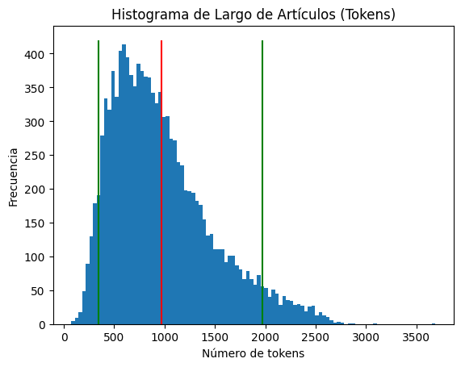

```python
plt.hist(article_tokenized_len, bins=100)
plt.vlines(np.percentile(article_tokenized_len, 5), 0, 420, color='green')
plt.vlines(np.mean(article_tokenized_len), 0, 420, color='red')
plt.vlines(np.percentile(article_tokenized_len, 95), 0, 420, color='green')
plt.xlabel('Número de tokens')
plt.ylabel('Frecuencia')
plt.title('Histograma de Largo de Artículos (Tokens)')
plt.show()
```

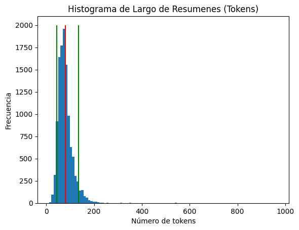

```python
plt.hist(summary_tokenized_len, bins=100)
plt.vlines(np.percentile(summary_tokenized_len, 5), 0, 2000, color='green')
plt.vlines(np.mean(summary_tokenized_len), 0, 2000, color='red')
plt.vlines(np.percentile(summary_tokenized_len, 95), 0, 2000, color='green')
plt.xlabel('Número de tokens')
plt.ylabel('Frecuencia')
plt.title('Histograma de Largo de Resumenes (Tokens)')
plt.show()
```

```python
print(bold('Largos de Artículos'))
print(f'percentil 1:  {np.percentile(article_tokenized_len, 1):5.1f}')
print(f'percentil 5:  {np.percentile(article_tokenized_len, 5):5.1f}')
print(f'promedio:     {np.mean(article_tokenized_len):5.1f}')
print(f'percentil 95: {np.percentile(article_tokenized_len, 95):5.1f}')
print(f'percentil 99: {np.percentile(article_tokenized_len, 99):5.1f}')
print()
print(bold('Largos de Resumenes'))
print(f'percentil 1:  {np.percentile(summary_tokenized_len, 1):5.1f}')
print(f'percentil 5:  {np.percentile(summary_tokenized_len, 5):5.1f}')
print(f'promedio:     {np.mean(summary_tokenized_len):5.1f}')
print(f'percentil 95: {np.percentile(summary_tokenized_len, 95):5.1f}')
print(f'percentil 99: {np.percentile(summary_tokenized_len, 99):5.1f}')
```

```
Largos de Artículos
percentil 1:  236.7
percentil 5:  345.0
promedio:     969.3
percentil 95: 1974.0
percentil 99: 2436.0

Largos de Resumenes
percentil 1:   32.0
percentil 5:   44.0
promedio:      79.3
percentil 95: 135.0
percentil 99: 174.0
```

### Evaluación

Empecemos a desarrollar nuestra evaluación. Utilizando la información de las distribuciones de los resumenes elegimos los mejores parámetros para evaluar en nuestro problema.

```python
eval_min_length = 32
eval_max_length = 135
eval_article_max_length = 768

eval_num_beams = 1
eval_batch_size = 128
```

También, creamos el objeto que nos ayudará a calcular los valores de ROUGE. Nuevamente utilizaremos un paquete que nos provee huggingface para esto, en este caso se llama `evaluate` y nos provee muchas de las métricas que se utilizan en machine learning.

```python
import evaluate

rouge = evaluate.load("rouge")
rouge_types = ['rouge1', 'rouge2', 'rougeL']

def compute_metrics(eval_pred):
    predictions, labels = eval_pred
    decoded_preds = tokenizer.batch_decode(predictions, skip_special_tokens=True)
    labels = np.where(labels != -100, labels, tokenizer.pad_token_id)
    decoded_labels = tokenizer.batch_decode(labels, skip_special_tokens=True)

    result = rouge.compute(predictions=decoded_preds, references=decoded_labels,
                           rouge_types=rouge_types, use_stemmer=True)

    prediction_lens = [np.count_nonzero(pred != tokenizer.pad_token_id) for pred in predictions]
    result["gen_len"] = np.mean(prediction_lens)

    return {k: round(v, 4) for k, v in result.items()}

def print_rouges(pred, tgt):
    labels = tokenizer(text_target=[random_summary], max_length=eval_max_length, truncation=True)
    scores = compute_metrics((pred, tgt))
    for score_type in rouge_types:
        score = scores[score_type]
        print(f'{score_type:6.6}: {score:.4f}')
```

### Inspección de Ejemplo

Inspeccionemos un ejemplo del dataset en el que vamos a evaluar y calculemos el ROUGE score sobre este. Nos permitirá entender mejor el tipo de ejemplos que existen en el dataset y hacernos una idea de como funciona el ROUGE score de manera más específica.

```python
dataset_len = len(cnndm)
rand_idx = random.randint(0, dataset_len)
random_article = cnndm['article'][rand_idx]
random_summary = cnndm['highlights'][rand_idx]
```

```python
prefix = "summarize: "
preprocess_text = random_article.strip().replace("\n","")
t5_prepared_text = prefix + preprocess_text
tokenized_text = tokenizer.encode(t5_prepared_text, return_tensors="pt").to(device)
target = tokenizer(text_target=[random_summary], max_length=eval_max_length, truncation=True)['input_ids']

summary_ids = model.generate(tokenized_text,
                             num_beams=20,
                             no_repeat_ngram_size=2,
                             num_return_sequences=1,
                             min_length=eval_min_length,
                             max_length=eval_max_length,
                             early_stopping=True).cpu()
output = tokenizer.decode(summary_ids[0], skip_special_tokens=True)

# pred = summary_ids.cpu()
tokenized_text = None # Free GPU memory
```

```python
print(bold("Texto Original:"))
print(textwrap.fill(random_article, width=80), end='\n\n')
print(bold("Resumen Gold Standard:"))
print(textwrap.fill(random_summary, width=80), end='\n\n')
print(bold("Resumen Generado:"))
print(textwrap.fill(output, width=80), end='\n\n')
print(bold("ROUGE Scores:"))
print_rouges(summary_ids, target)
```

```
Texto Original:
England captain Alastair Cook completed a much-needed century on the second
morning of England's opening tour match in the West Indies. Cook resumed on 95
and reached three figures with minimal fuss before retiring out. England captain
Alastair Cook completed a century on the second morning of England's opening
tour match . A controlled thick edge from the first ball of the day brought him
an 11th boundary of the innings and in the following over he punched the ball
for two off the back foot. He offered a gentle wave of the bat and a handshake
to partner Gary Ballance and walked off on 101 from 200 deliveries. That allowed
Ian Bell to arrive at the crease, with batting time more important to the
tourists than attempting to force a result in this two-day fixture. Ian Bell
plays to the offside during day two of the St Kitts and Nevis Invitational XI
versus England tour match .

Resumen Gold Standard:
Alastair Cook completed his century on the second morning of action . England
captain resumed on 95 and reached three figures before retiring . That allowed
Ian Bell to arrive at the crease as tourists continued to bat .

Resumen Generado:
alastair cook completed a much-needed century on the second morning of England's
opening tour match in the west indies. the captain resumed on 95 and reached
three figures with minimal fuss before retiring out.

ROUGE Scores:
rouge1: 0.5833
rouge2: 0.4286
rougeL: 0.5556
```

### Evaluación Completa sobre CNN/DailyMail

Finalemente efectuemos la evaluación sobre todo el set de test.

Dado que el dataset original contiene texto, es necesario primero tokenizar ese texto de manera de tener valores numéricos que nuestro modelo pueda procesar. Para eso lo primero es preprocesar el dataset, generamos una función con este fin: `preprocess_function`.

```python
def preprocess_function(examples):
    inputs = [prefix + doc.strip().replace("\n","") for doc in examples["article"]]
    model_inputs = tokenizer(
        inputs, max_length=eval_article_max_length, truncation=True)

    labels = tokenizer(
        text_target=examples["highlights"], max_length=eval_max_length, truncation=True)

    model_inputs["labels"] = labels["input_ids"]
    return model_inputs
```

Efectuamos el preprocesamiento y creamos un `DataLoader` que nos permita iterar de forma eficientemente sobre los datos.

```python
from transformers import DataCollatorForSeq2Seq
import multiprocessing

cores = multiprocessing.cpu_count() # Count the number of cores in a computer

tokenized_cnndm = cnndm.map(preprocess_function, batched=True)
tokenized_cnndm = tokenized_cnndm.remove_columns(cnndm.column_names)

data_collator = DataCollatorForSeq2Seq(tokenizer=tokenizer, model=t5_model)

loader = DataLoader(tokenized_cnndm, batch_size=eval_batch_size,
                    collate_fn=data_collator, shuffle=True, num_workers=cores,
                    pin_memory=True)
```

Finalmente haremos la evaluación.

```python
model.eval()

all_predictions = []
all_labels = []

for batch in tqdm(loader):
    inputs = {k: v.to(device) for k, v in batch.items() if k != 'labels'}
    labels = batch['labels'].to(device)

    with torch.no_grad():
        generated_tokens = model.generate(
            **inputs,
            max_length=eval_max_length,
            num_beams=eval_num_beams,
            no_repeat_ngram_size=2,
            early_stopping=True,
        )

    all_predictions.extend(generated_tokens.cpu().numpy())
    all_labels.extend(labels.cpu().numpy())

all_predictions = np.stack(all_predictions)
all_labels = np.stack(all_labels)

rouge_results = compute_metrics((all_predictions, all_labels))
```

E imprimimos el resultado de los distintos scores de ROUGE en nuestro dataset:

```python
print(bold("ROUGE Scores promedio:"))
for score_type in rouge_types:
    score = rouge_results[score_type]
    print(f'{score_type:6.6}: {score:.4f}')
```

```
ROUGE Scores promedio:
rouge1: 0.3489
rouge2: 0.1311
rougeL: 0.2265
```

## Actividad 4

En el trabajo en que propusieron y probaron T5 ellos reportan los siguientes resultados en este dataset:

**ROUGE-1 :** 41.12

**ROUGE-2 :** 19.56

**ROUGE-L :** 38.35

```python
# @title ¿Por qué nuestro model no alcanzó el mismo rendimento de ROUGE que el reportado en el trabajo original? De *dos razones* concretas.
R1 = "Usamos un modelo mucho más pequeño. Trabajamos con t5-small (60 millones de parámetros), mientras que el paper reporta con versiones bastante más grandes de T5 (t5-base de 220 millones y hasta t5-11B de 11 mil millones). Un modelo más chico tiene menos capacidad para generar buenos resúmenes, y eso baja el ROUGE." # @param {"type":"string"}
R2= "Se cortaron los artículos. Medimos que el artículo promedio tiene unos 969 tokens, pero en la evaluación se truncó a 768, así que en la mayoría de los casos el modelo no vio la parte final del texto y resumió con información incompleta, lo que reduce el ROUGE." # @param {"type":"string"}
```

```python
# @title Proponga una mejora a lo que hicimos en el laboratorio para mejorar el rendimiento. Esta no debe considerar modificar ninguno de los parámetros que hemos utilzado acá. Responda brevemente:
M = "Fine-tunear el modelo sobre el dataset CNN/DailyMail. En el laboratorio usamos T5 tal como viene pre-entrenado, sin entrenarlo para esta tarea específica; si lo entrenáramos con los datos de entrenamiento de CNN/DailyMail, aprendería el estilo y el largo de los resúmenes de noticias y daría mejores resultados. El paper reporta justamente resultados después de fine-tunear." # @param {"type":"string"}
```